# MPG Comparisons between Manual and Automatic Transmissions

J.E. Turcotte

May 17, 2016

## Synopsis

In this brief study, we must explore the effect that automatic versus manual transmissions has over miles-per-gallon fuel efficiency among a sample group of 1974 model automobiles.

## Assumptions

Having examined the data beforehand, I’ve made the following assumptions: * The field ‘qsec’ (or, from a stop, how many seconds it took for the vehicle to reach a quarter mile’s distance) is likely a function of the car’s power; i.e., a result, like miles per gallon, of the vehicle’s configuration rather than a potential confounding cause OF miles per gallon. For that reason, I’m excluding it in any modelling of miles per gallon per vehicle. * Given the yes-or-no nature of whether or not a car is manufactured with or without automatic transmission, this data has been categorized, so named within the data, and is likely to be modelled using binomial logistic regression.

## Examining the Data

Following this, *Table 2* gives us a brief summarization of the better-named data that remains, excluding a few extra columns for brevity.

## Source

Henderson and Velleman (1981), *Building multiple regression models interactively*. Biometrics, 37, 391–411.

## Appendix

Looking at the Data

|  | mpg | cyl | disp | hp | drat | wt | am | gear | carb |
| --- | --- | --- | --- | --- | --- | --- | --- | --- | --- |
| **Mazda RX4** | 21 | 6 | 160 | 110 | 3.9 | 2.62 | 1 | 4 | 4 |
| **Mazda RX4 Wag** | 21 | 6 | 160 | 110 | 3.9 | 2.875 | 1 | 4 | 4 |
| **Datsun 710** | 22.8 | 4 | 108 | 93 | 3.85 | 2.32 | 1 | 4 | 1 |
| **Hornet 4 Drive** | 21.4 | 6 | 258 | 110 | 3.08 | 3.215 | 0 | 3 | 1 |
| **Hornet Sportabout** | 18.7 | 8 | 360 | 175 | 3.15 | 3.44 | 0 | 3 | 2 |
| **Valiant** | 18.1 | 6 | 225 | 105 | 2.76 | 3.46 | 0 | 3 | 1 |

Studying the Data

| MPG | cylinders | horsepower | tons | manual |
| --- | --- | --- | --- | --- |
| Min. :10.40 | Min. :4.000 | Min. : 52.0 | Min. :0.7565 | Min. :0.0000 |
| 1st Qu.:15.43 | 1st Qu.:4.000 | 1st Qu.: 96.5 | 1st Qu.:1.2906 | 1st Qu.:0.0000 |
| Median :19.20 | Median :6.000 | Median :123.0 | Median :1.6625 | Median :0.0000 |
| Mean :20.09 | Mean :6.188 | Mean :146.7 | Mean :1.6086 | Mean :0.4062 |
| 3rd Qu.:22.80 | 3rd Qu.:8.000 | 3rd Qu.:180.0 | 3rd Qu.:1.8050 | 3rd Qu.:1.0000 |
| Max. :33.90 | Max. :8.000 | Max. :335.0 | Max. :2.7120 | Max. :1.0000 |

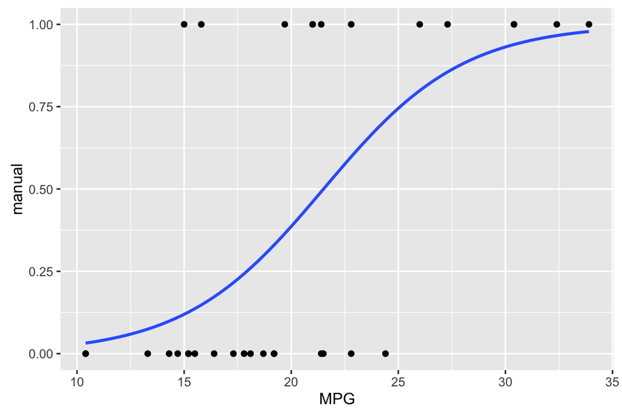